# Le Champ des Possibles : Une prairie urbaine communautaire et biodiversifiée

Dominique Boulet

07.2022

[video not shown]

Situé dans le quartier du Mile End, le long de la voie ferrée du Canadien Pacifique et délimité par le monastère des Carmélites à l’est et d’anciens ateliers de confection à l’ouest, le Champ des Possibles est un espace vert local unique. Aujourd’hui une prairie urbaine protégée, le Champ des Possibles a connu une histoire intéressante qui a récemment mené à son statut protégé et à une structure de gouvernance unique de cogestion entre un organisme communautaire sans but lucratif, Les Amis du Champ des Possibles, et l’arrondissement du Plateau-Mont-Royal. Différent des autres parcs avoisinants, le nom de cet espace lui convient bien avec le large éventail d’usages et d’appropriations qui s’y déroulent. Pour ceux qui fréquentent et prennent soin du Champ des Possibles, il est devenu un lieu important pour démontrer comment une communauté peut s’impliquer dans la gestion officielle d’un espace de type parc. Il est connu pour ses caractéristiques “sauvages” et “naturelles”, mais cela n’a pas toujours été le cas. Le Champ des Possibles s’est transformé au cours des 150 dernières années, passant d’une carrière à un dépotoir, à une gare de triage, pour devenir progressivement l’espace qu’il est aujourd’hui (Desjardins, 2019). Simultanément, le quartier environnant du Mile End a subi de nombreux changements et a connu une forte gentrification. Dans sa trajectoire pour devenir le quartier populaire qu’il est aujourd’hui, il s’est transformé d’un arrêt sur la ligne ferroviaire, au quartier du vêtement de Montréal, à une plaque tournante pour les entreprises technologiques (Desjardins, 2019 ; McSwiney & Michaud, 2014). Les changements physiques et sociaux au fil des décennies ont façonné la réalité actuelle du quartier et de ses espaces tels que le Champ des Possibles. L’histoire du Champ des Possibles et de sa structure de gouvernance actuelle de cogestion, qui met l’accent sur la prise de décision par la communauté, illustre comment la spontanéité et le relâchement peuvent être positifs dans le contexte de la planification urbaine, tant pour les politiques que pour le design.

[figure not shown]

Image 1.Champ des Possibles

Dans les années 1850, le terrain où se trouve actuellement le Champ des Possibles comptait plusieurs carrières. À cette époque, la région était encore rurale et, à la fin du XIXe siècle, les carrières étaient abandonnées (Desjardins, 2019). Certaines ont simplement été laissées sans entretien et sont devenues dangereuses, tandis que d’autres ont été transformées en dépotoirs, comme le Champ des Possibles (Desjardins, 2019). Finalement, au début des années 1900, le dépotoir a été rempli et, en 1906, le Canadien Pacifique a acheté le terrain et l’a utilisé comme cour de triage pour entreposer ses wagons. Entre 1950 et 1975, de grandes usines de textile ont été construites dans la région et certaines de ces mégastructures qui abritaient ces usines sont encore là aujourd’hui (McSwiney et Michaud, 2014). Avec la présence de l’industrie textile et de la gare de triage, des travailleurs et des services sont arrivés dans le secteur et le Mile End s’est rapidement transformé en un centre urbain (McSwiney & Michaud, 2014). La gare de triage a été fermée au milieu des années 1980 et le champ a été laissé libre de pousser et, grâce à ce processus de ré-ensauvagement spontané, il a gagné une grande biodiversité (McSwiney & Michaud, 2014). Cela était dû à son emplacement, où des graines étaient apportées par les trains à proximité et où les gens semaient des graines et plantaient eux-mêmes de la végétation (McSwiney & Michaud, 2014). Puisque l’espace a été laissé en grande partie intact jusqu’à récemment, il y a encore des signes physiques de l’histoire de l’espace : les bâtiments le long de l’avenue de Gaspé sont courbés pour accueillir les anciennes lignes de train, il y a des quais de chargement en ruine et des voies ferrées enterrées (McSwiney et Michaud, 2014).

Le Chemin de fer Canadien Pacifique (CFCP) était officiellement propriétaire du terrain jusqu’en 2005, date à laquelle l’arrondissement du Plateau-Mont-Royal en a pris possession (Poteete et al., 2021). Au début, la ville allait utiliser le terrain comme cour de service, mais rapidement, de nombreuses propositions ont été faites pour le secteur (Beaudin, 2013). Avec l’acquisition du lot par l’arrondissement au début des années 2000, l’intérêt pour le potentiel de développement du secteur s’est accru. De nombreuses études ont été réalisées afin de déterminer comment développer le secteur Est de Saint-Viateur, qui est délimité par les rues Saint Denis, Saint Laurent, Maguire, et la voie ferrée. Au départ, la priorité du plan d’aménagement était d’augmenter l’accessibilité véhiculaire et la connectivité du secteur (Desjardins, 2021). Il était proposé de relier l’avenue Saint-Viateur à la rue Henri-Julien en construisant une route reliant les deux, où il y a maintenant une voie piétonnière et cyclable. L’avenue du Carmel devait également être prolongée jusqu’à la rue Alma afin de créer un nouveau lien derrière les immeubles de l’avenue de Gaspé (Desjardins, 2021). En plus de ces nouvelles routes, la proposition prévoyait l’expropriation et la démolition de bâtiments comme le 5555 avenue de Gaspé, qui abritait de nombreux ateliers d’artistes et constituait un élément caractéristique du quartier à l’époque (Desjardins, 2021). Des immeubles résidentiels devaient également être construits dans le secteur et sur le site du Champ des Possibles. Plusieurs facteurs ont fait en sorte que ces propositions n’ont pas été réalisées.

En 2005, par suite d’une mobilisation citoyenne, le monastère des Carmélites situé à proximité a été classé monument historique par le ministère de la Culture (Desjardin, 2021). Le secteur, comprenant le Champ des possibles adjacent, est donc devenu protégé et plusieurs contraintes de construction ont été mises en place. Il existe des restrictions de hauteur pour tout nouveau bâtiment dans la zone et la tranquillité est un objectif explicite (Desjardins, 2021). Deux actions majeures documentées ont spécifiquement remis en cause le développement du champ : le Roerich Garden Project et Sprout Out Loud (McSwiney & Michaud, 2014). Le Roerich Garden Project a été créé en 2007 pour ” provoquer un dialogue sur les nombreuses façons dont la communauté utilise et interagit avec le champ ” (McSwiney & Michaud, 2014, p. 272). Ce projet a été initié dans le Champ des Possibles, connu à l’époque sous le nom de Maguire Meadow ou le champ, par Emily Rose Michaud (site web). Le jardin était un symbole Roerich de 312 pieds carrés composé de matériaux vivants et a été entretenu pendant trois ans par Sprout Out Loud. Le symbole Roerich a été créé et utilisé pour protéger les monuments historiques, culturels et scientifiques des bombardements aériens pendant la Seconde Guerre mondiale (McSwiney et Michaud, 2014). Construire un jardin vivant sous la forme de ce symbole était une façon d’interpeller et de réfléchir aux usages et au développement potentiel du Champ des Possibles (Michaud, s.d.). Le projet a permis aux citoyens de se rassembler et de mieux définir ce qu’ils voulaient pour cet espace et de réfléchir de manière critique aux plans de développement de la ville (Michaud, n.d.).

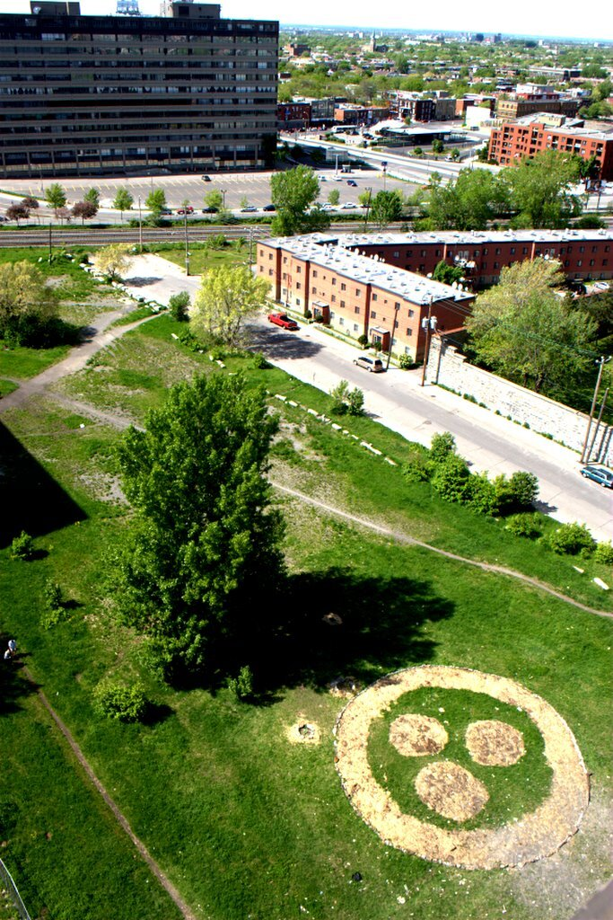

Image 2.Le projet de jardin Roerich, photo prise de from http://emilyrosemichaud.com/portfolio-item/roerich-garden-project

En 2008, la ville a annoncé qu’elle commencerait à développer le secteur Saint-Viateur Est, et une autre initiative a suivi pour protéger formellement l’espace. Un autre groupe communautaire, le Comité des citoyens du Mile End, a tenu un forum de citoyens qui abordait les plans à venir de la ville pour le développement de 9 millions de dollars du quartier Mile End (McSwiney et Michaud, 2014). Suite à ce forum, la résistance de la communauté pour le réaménagement du Champ des Possibles par la ville a été renforcée. Au même moment, un changement de gouvernement a eu lieu au niveau municipal. En 2009, Projet Montréal balaie le conseil d’arrondissement en remportant tous les sièges, ce qui contribuera également aux décisions de l’administration municipale concernant le Champ des Possibles et plus largement le secteur de Saint-Viateur Est (Desjardins, 2021). Les actions entreprises dans le Champ des Possibles, combinées à la réaction de la communauté du quartier plus large et au changement de leadership politique, ont été un catalyseur pour proposer des plans alternatifs (McSwiney & Michaud, 2014). Le Comité des citoyens du Mile End a mobilisé un sous-comité pour développer et proposer des options qui représenteraient et serviraient mieux les habitants du quartier (McSwiney & Michaud, 2014). Finalement, Les Amis du Champ des Possibles a été créé à partir de cet effort avec l’objectif de collaborer avec l’arrondissement et la municipalité pour défendre les préoccupations de la communauté locale (McSwiney & Michaud, 2014).

Les Amis du Champ des Possibles (ACDP) ont été officiellement formés en 2010 en tant qu’organisation à but non lucratif avec trois objectifs principaux :

> faire du Champ des Possibles un espace vert public permanent et une réserve de biodiversité urbaine ; promouvoir et encourager l’éducation du public aux sciences naturelles, à l’histoire et à l’art ; promouvoir la création de nouveaux espaces verts urbains et de corridors de biodiversité. (Poteete et al., 2021)

Depuis 2013, l’ACDP dispose d’une entente formelle de cogestion avec l’arrondissement du Plateau-Mont-Royal. En mai de la même année, le site a été officiellement reconnu comme un espace vert naturel. L’entente de cogestion est entrée en vigueur en même temps que le nouveau plan de réaménagement de l’arrondissement pour Saint-Viateur Est. Les objectifs de ce plan étaient les suivants : établir des conditions plus favorables aux artistes et aux industries créatives et technologiques ; revoir l’utilisation des premiers étages pour favoriser l’animation du secteur ; officialiser la création d’un parc ; et protéger l’intégrité patrimoniale du Monastère des Carmes (Plateau-Mont-Royal, 2013). C’est ainsi qu’est née la voie piétonne et cyclable existante qui relie l’avenue de Gaspé et la rue Henri-Julien dans le Champ des Possibles.

[figure not shown]

Image 3.La voie piétonne et cyclable entre l’avenue de Gaspé et la rue Henri-Julien.

Le premier accord de cogestion entre l’ACDP et l’arrondissement du Plateau-Mont-Royal était d’une durée de quatre ans, une version révisée a été mise en place en 2017 et a expiré en 2019 et a depuis été renouvelée. Au cours de l’année 2020, un projet de recherche en partenariat intitulé *Soutenir les possibilités de mise en commun urbaine dans le Champ des Possibles de Montréal* a débuté entre l’ACDP, la professeure Amy Poteete de l’Université Concordia et le professeur Nik Luka de l’Université McGill. L’objectif de ce projet est de coproduire des connaissances sur les usages, les intérêts et les aspirations futures du Champ des Possibles. Ce projet, toujours en cours, est mené par une équipe pluridisciplinaire qui utilise diverses méthodes de recherche telles que des observations directes, des observations participatives, des groupes de discussion, des entretiens et des questionnaires. Bien que la structure de cogestion ait jusqu’à présent abouti à une approche non interventionniste du développement du Champ des Possibles, un plan de décontamination du site est en place et devrait débuter au cours de l’année prochaine. Compte tenu de l’embourgeoisement rapide des quartiers environnants et de l’attrait du site pour ceux qui ont des intérêts financiers, les partenaires du projet *Soutenir les possibilités de mise en commun urbaine au Champ des Possibles de Montréal* sont soucieux de trouver des moyens de s’assurer que les pratiques de mise en commun puissent se poursuivre et que les voix de la communauté restent une partie importante du processus de développement.

L’implication de la communauté fait partie de ce qui fait du Champ des Possibles un espace vert local unique. Cela se manifeste non seulement dans la façon dont le Champ des Possibles est devenu un espace vert protégé officiel, ou dans sa structure de gouvernance de cogestion en cours, mais aussi dans la façon dont il est utilisé et dans les aspirations des utilisateurs. En 2021, le projet *Soutenir les possibilités de mise en commun urbaine dans le Champ des Possibles de Montréal* a publié son premier rapport qui présente des résultats intéressants concernant les activités qui ont lieu dans le Champ des Possibles et les souhaits des gens quant à l’avenir de l’espace et de sa gestion. L’un des intérêts des chercheurs était d’examiner les soins et l’intendance du Champ des Possibles. Poteete et al. (2021) ont constaté que l’activité la plus courante et la plus fréquente était l’élimination des déchets, tandis que les autres activités comprenaient l’élimination des obstacles physiques au site et l’entretien des chemins et autres caractéristiques du site.

L’élimination des barrières physiques du site est un problème permanent dans le Champ des Possibles, notamment la découpe de trous dans la clôture le long de la voie ferrée, comme le montre la photo ci-dessous. Depuis 2011, l’arrondissement du Plateau-Mont-Royal est en négociation avec le Canadien Pacifique et Transports Canada concernant la construction d’un passage à niveau qui permettrait aux piétons et aux cyclistes de circuler en toute sécurité au-dessus des voies ferrées (Norris, 2019). Les sentiers informels qui sont continuellement défendus par les citoyens sont une indication claire de la nécessité de relier en toute sécurité le Champ des Possibles, et le Mile End, à Rosemont (Norris, 2019). En 2019, le dossier de Montréal pour un passage à niveau était toujours à l’étude par un tribunal de Transports Canada (Norris, 2019). En 2022, le débat a refait surface après qu’un accident mortel se soit produit au passage informel de la rue Van Horne et de la rue Saint-Laurent (Samson, 2022). Selon les informations, à la suite de l’accident la police ferroviaire aurait commencé à donner des amendes de 650$ aux personnes qui traversent les voies ferrées et les résidents du secteur ont exprimé leur frustration face à la situation actuelle (Samson, 2022). Le sentiment ressenti par de nombreux résidents est que les chemins alternatifs sont peu pratiques, qu’ils ajoutent environ 20 à 30 minutes de temps de trajet et qu’ils sont désagréables pour les piétons (Samson, 2022). Certains répondants de l’étude de Poteete et al. (2021) perçoivent le maintien de ces passages informels comme une façon de prendre soin ou de participer à l’intendance du Champ des Possibles.

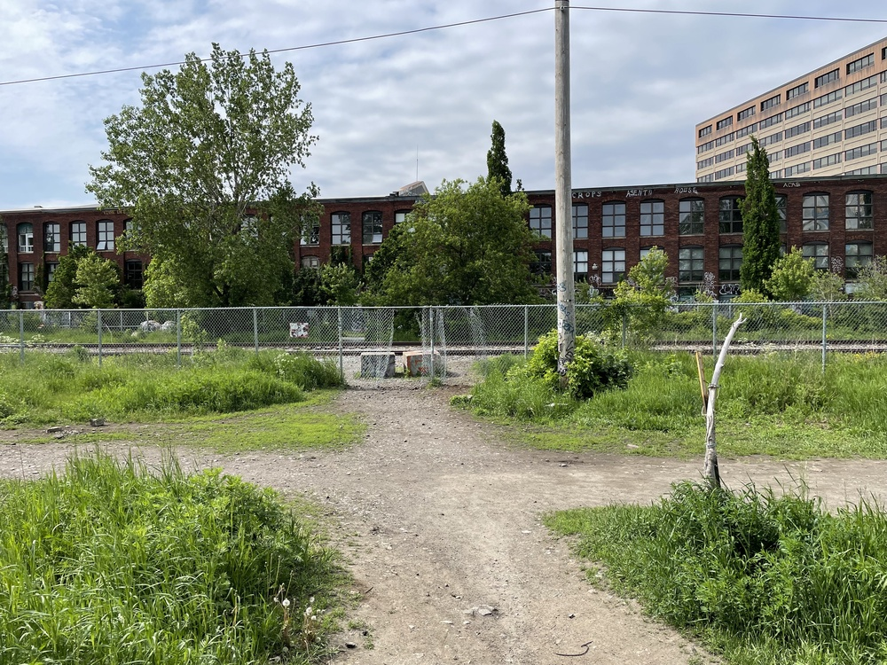

Image 4.Traversée informelle de la clôture de la voie ferrée du CP

Dans le cadre du thème de soin et de l’intendance, les répondants ont également été interrogés sur leur stratégie de gestion souhaitée concernant la végétation du Champ des Possibles. Les résultats de Poteete et al. (2021) indiquent que la stratégie la moins souhaitée est une stratégie conventionnelle avec des pelouses et de la verdure décorative, où les répondants ont compris l’intendance actuelle du Champ des Possibles comme permettant sa croissance libre et comme un rejet de l’aménagement paysager typique des parcs urbains. C’est précisément ce type de “sauvagerie”, tant en termes de verdure que d’orientation communautaire, qui est important et exemplaire pour nombre de ses visiteurs (Poteete et al., 2021).

Pour de nombreuses personnes interrogées dans le cadre de la recherche de Poteete et al. (2021), l’accès à des espaces verts tels que le Champ des Possibles, où les individus peuvent interagir étroitement avec divers types de végétation, de petits animaux et d’insectes, est sous-estimé dans un contexte urbain. La biodiversité et les caractéristiques “naturelles” du Champ des Possibles sont mises en avant, car pour beaucoup, cet espace offre un répit et un contraste positif avec les grands bâtiments environnants (Poteete et al., 2021). Le caractère ” sauvage ” du Champ des Possibles est l’un de ses paradoxes ; pour certains, il représente ce qu’ils aiment le plus de l’espace, tandis que pour d’autres, il représente une gestion non structurée. Une approche non-interventionniste qui permet la biodiversité et les espaces verts “naturels” du Champ des Possibles laisse également la place à des comportements qui endommagent l’espace comme “les déchets et les décharges illégales, l’allumage de feux de camp, le bruit et la destruction de certaines plantes” (Poteete et al., 2021, p. 13). Pour l’instant, le Champ des Possibles peut s’accommoder de ce paradoxe et permet aux deux réalités de coexister. Bien sûr, la question est de savoir si et pendant combien de temps le Champ des Possibles pourra continuer à être ce type d’espace vert liminal, équilibrant délicatement ce paradoxe.

[figure not shown]

Image 5.Une fosse à feu et une installation artistique dans le Champ des Possibles

Sa trajectoire historique illustre la façon dont l’implication de la communauté est une partie importante de l’identité du Champ des Possibles et de la structure de gouvernance actuelle de cogestion. Avec le plan de décontamination du site à venir, des changements physiques seront inévitables. Les recherches de Poteete et al. (2021) soulignent l’importance de cet espace et de sa biodiversité pour sa communauté et les zones environnantes plus larges. La gestion et le développement du Champ des Possibles qui ont eu lieu au cours de la dernière décennie montrent la complexité ainsi que les avantages d’une approche non-interventionniste à la fois pour la politique et la conception. L’existence d’un accord de cogestion entre l’ACDP et l’arrondissement du Plateau-Mont-Royal a permis d’assurer que les voix de la communauté fassent partie des processus de gestion et de développement. De ce fait, le Champ des Possibles n’est pas devenu comme les autres parcs urbains et est resté en grande partie “sauvage” et “naturel”. L’absence de conception manucurée est précisément ce que beaucoup apprécient dans cet espace vert et souhaitent qu’il continue (Poteete et al., 2021). Cette liberté laisse place à la spontanéité et à l’appropriation, qui peuvent avoir des conséquences positives et négatives, se manifestant de nombreuses façons, comme l’enlèvement des ordures ou la réalisation de feux de joie qui peuvent être nuisibles (Poteete et al., 2021). La coopération entre les organisations de base et, finalement, l’arrondissement, a permis de créer un espace moins structuré, tant physiquement que socialement. Cela a permis à la végétation de pousser plus librement et à une multitude de comportements et d’activités d’avoir lieu dans le Champ des Possibles. Des espaces verts tels que celui-ci sont rares, et le Champ des Possibles peut servir d’exemple pour les avantages de la fusion des approches ascendantes et descendantes de l’aménagement urbain.

### References

Beaudin, M. 2013. “Mile End Green Space Gets Protected Status,” *Montreal Gazette* (23 May 2013) Retrieved May 30, 2022, from https://www.pressreader.com/canada/montreal-gazette/20130523/281608122963993.

Desjardins, Y. (2019, January 22). *Le ” passé antérieur ” du champ des possibles.* Le ” passé antérieur ” du Champ des Possibles – Mémoire du Mile End. Retrieved May 17, 2022, from http://memoire.mile-end.qc.ca/fr/le-passe-anterieur-du-champ-des-possibles/

Desjardins, Y. (2021, May 22). *The Mile End Citizens’ Committee during the 2000s.* Mile End Memories. Retrieved May 30, 2022, from http://memoire.mile-end.qc.ca/en/le-comite-des-citoyens-du-mile-end-les-annees-2000/

McSwiney, O., & Michaud, E. R. (2014). Le Champ des Possibles—The Field of Possibilities. In M. Ratto & M. Boler (Eds.), *DIY citizenship : critical making and social media* (pp. 269–281). Cambridge MA : MIT Press.

Michaud, E. R. (n.d.). *[The] Roerich Garden Project.* Retrieved May 17, 2022 from http://emilyrosemichaud.com/portfolio-item/roerich-garden-project

Norris, Alex. 2019. *Les Passages a Niveau Cyclo-Pedestres.* Le Plateau-Mont-Royal. http://ville.montreal.qc.ca/pls/portal/docs/PAGE/ARROND_PMR_FR/MEDIA/DOCUMENTS/PRES_PASSAGENIVEAU_VFINALE2019.PDF

Plateau-Mont-Royal, 2013. Assemblée publique de consultation: Règlement d’urbanisme de l’arrondissement du Plateau-Mont-Royal relative au secteur Saint-Viateur Est. Le Plateau-Mont-Royal. (11 September 2013). http://ville.montreal.qc.ca/pls/portal/docs/PAGE/ARROND_PMR_FR/MEDIA/DOCUMENTS/SVE_HISTORIQUE_CONSULTATION_2013-09-11.PDF. Accessed on 1 June 2022.

Poteete, A. et al. (2021). (rep.). *Supporting the Possibilities of Urban Commoning in Montréal’s Champ des Possibles* (pp. 1–25). Montreal, QC.

Samson, F. (2022, March 6). *Montreal’s mile end residents fight for pedestrian crossing after Train hits woman | cbc news. CBC news.* Retrieved June 2, 2022, from https://www.cbc.ca/news/canada/montreal/montreal-mile-end-pedestrian-crossing-canadian-pacific-1.6374736